# **Panorama da inflação**

Os principais índices de inflação do Brasil, apontam em julho de 2016 um avanço da inflação de em média **0.45%**. Com esse resultado, no ano a inflação acumula uma variação média positiva de **5.21%**, e em 12 meses uma variação média acumulada de **9.98%**.

|  | Variação mensal | Variação acumulada no ano | Variação acumulada em 12 meses |
| --- | --- | --- | --- |
| IPCA | 0.52% | 4.96% | 8.74% |
| INPC | 0.64% | 5.76% | 9.56% |
| IGP-M | 0.18% | 4.9% | 11.63% |
| IGP-DI | -0.39% | 4.02% | 11.23% |
| IPA | -0.81% | 0.06% | 0.13% |
| IPC | 0.37% | 3.05% | 8.37% |
| INCC | 0.49% | 4.29% | 6.4% |

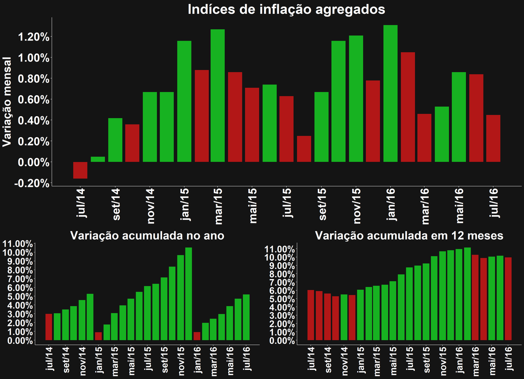

Índices selecionados para a média: IPCA, INPC e IGP-M.

# IPCA

|  | 07/2015 | 06/2016 | 07/2016 |
| --- | --- | --- | --- |
| Variação mensal | 0.62% | 0.35% | 0.52% |
| Variação acumulada no ano | 6.83% | 4.42% | 4.96% |
| Variação acumulada em 12 meses | 9.56% | 8.84% | 8.74% |

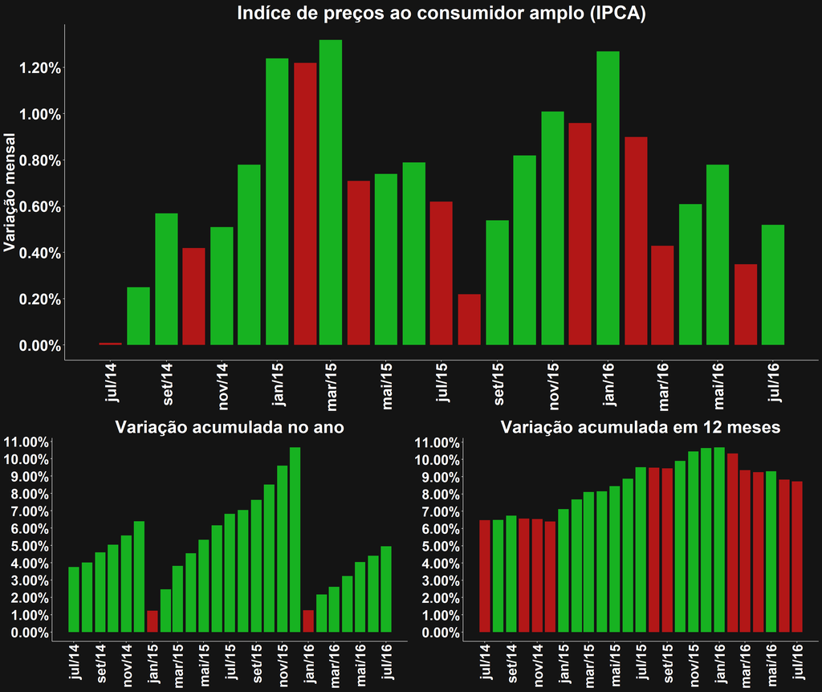

Os grupos que tiveram maior resultado positivo foram Alimentação e bebidas (1.32%) e Despesas pessoais (0.7%), e negativo Vestuário (-0.38%) e Habitação (-0.29%).

|  | Variação mensal | Variação acumulada no ano | Peso mensal |
| --- | --- | --- | --- |
| Alimentação e bebidas | 1.32% | 8.79% | 25.94% |
| Habitação | -0.29% | 1.76% | 15.39% |
| Artigos de residência | 0.53% | 3.9% | 4.23% |
| Vestuário | -0.38% | 1.95% | 6% |
| Transportes | 0.4% | 1.87% | 17.92% |
| Saúde e cuidados pessoais | 0.61% | 8.18% | 11.48% |
| Despesas pessoais | 0.7% | 5.3% | 10.65% |
| Educação | 0.04% | 7.44% | 4.66% |
| Comunicação | 0.02% | 0.75% | 3.74% |

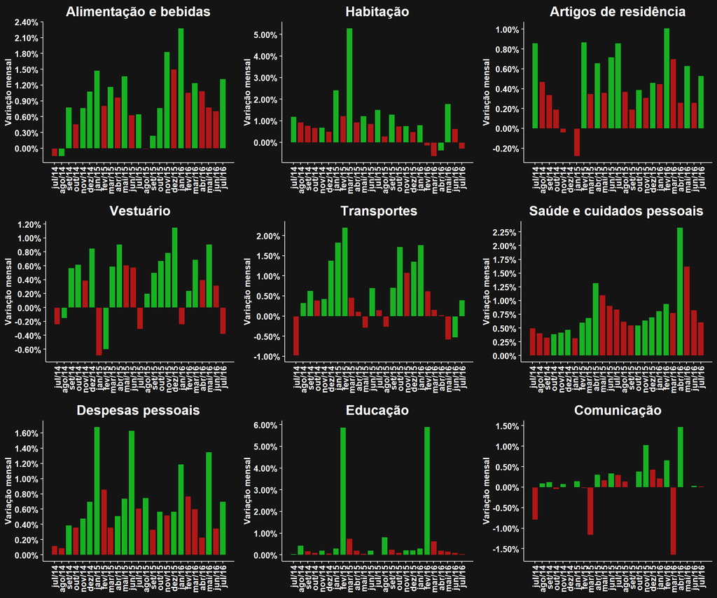

A nível de sub-itens os que mais influenciaram positivamente no resultado em relação ao seu peso foram Leite longa vida (17.58%%) e Feijão - carioca (rajado) (32.42%%), e negativamente Energia elétrica residencial (-3.04%%) e Batata-inglesa (-20%%).

|  | Variação mensal | Variação acumulada no ano | Peso mensal |
| --- | --- | --- | --- |
| Feijão - carioca (rajado) | 32.42% | 150.61% | 0.39% |
| Passagem aérea | 19.22% | -25.39% | 0.31% |
| Leite longa vida | 17.58% | 48.99% | 1.1% |
| Plano de saúde | 1.08% | 7.68% | 3.38% |

|  | Variação mensal | Variação acumulada no ano | Peso mensal |
| --- | --- | --- | --- |
| Batata-inglesa | -20% | 23.25% | 0.41% |
| Mamão | -26.97% | 4.42% | 0.12% |
| Cebola | -28.37% | -22.68% | 0.18% |
| Energia elétrica residencial | -3.04% | -7.69% | 3.66% |

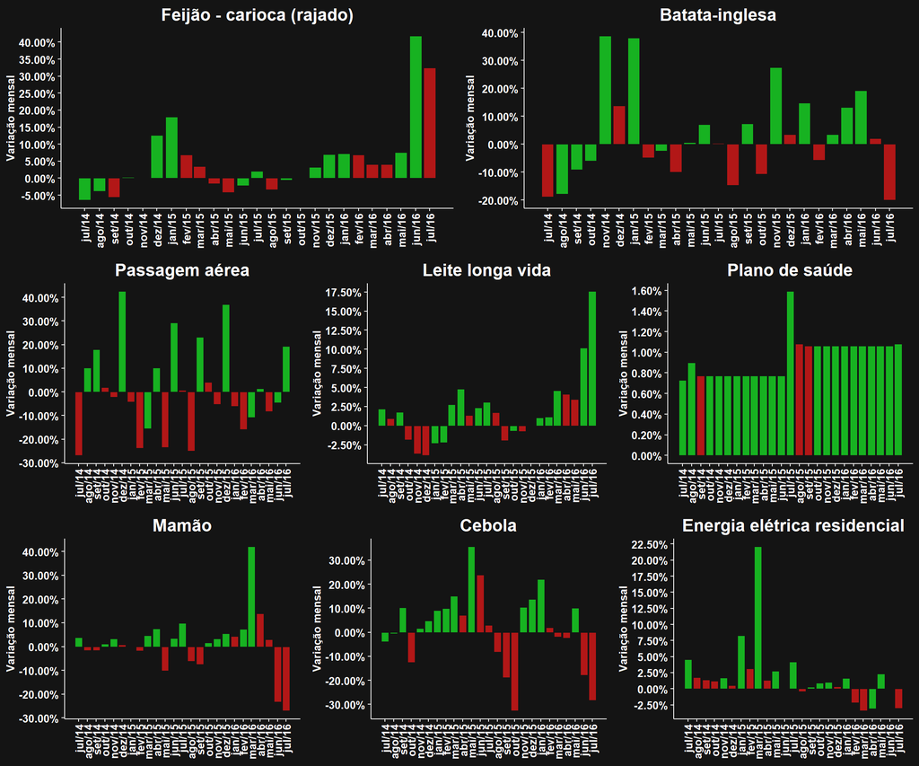

# INPC

O Indíce Nacional de Preços ao Consumidor (INPC) variou 0.64% em julho, valor superior ao mesmo período do ano anterior quando apresentou uma taxa de 0.58%. Com esse resultado o indíce acumula no ano uma variação positiva de 5.76%, e em 12 meses uma variação positiva de 9.56%.

|  | 07/2015 | 06/2016 | 07/2016 |
| --- | --- | --- | --- |
| Variação mensal | 0.58% | 0.47% | 0.64% |
| Variação acumulada no ano | 7.42% | 5.09% | 5.76% |
| Variação acumulada em 12 meses | 9.81% | 9.49% | 9.56% |

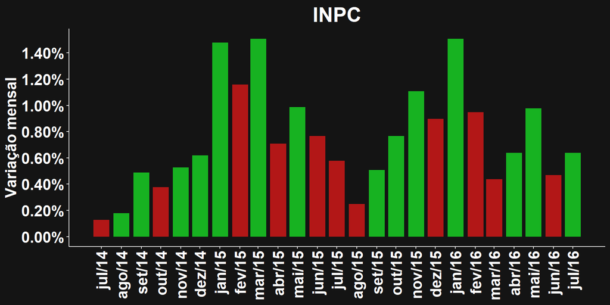

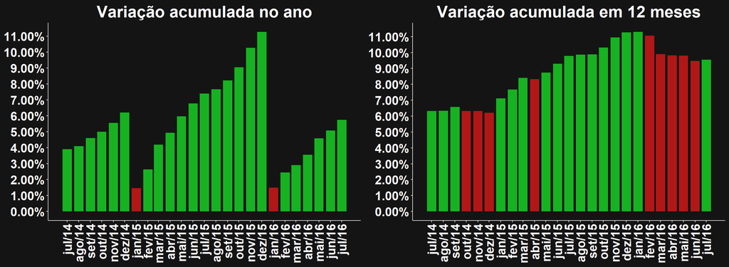

# IGP-M

|  | 07/2015 | 06/2016 | 07/2016 |
| --- | --- | --- | --- |
| Variação mensal | 0.69% | 1.69% | 0.18% |
| Variação acumulada no ano | 4.26% | 4.72% | 4.9% |
| Variação acumulada em 12 meses | 6.97% | 12.21% | 11.63% |

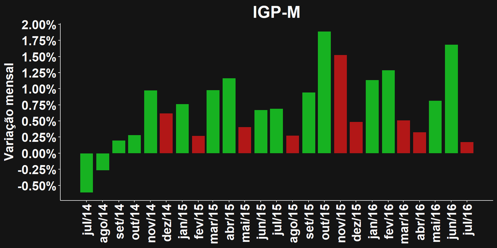

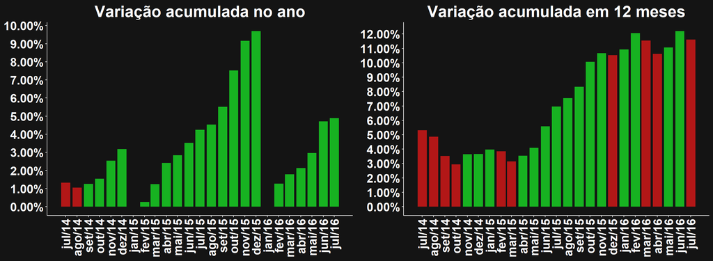

# IGP-DI

O Indíce Geral de Preços - Disponibilidade Interna (IGP-DI) variou -0.39% em julho, valor inferior ao mesmo período do ano anterior quando apresentou uma taxa de 0.58%. Com esse resultado o indíce acumula no ano uma variação positiva de 4.02%, e em 12 meses uma variação positiva de 11.23%.

|  | 07/2015 | 06/2016 | 07/2016 |
| --- | --- | --- | --- |
| Variação mensal | 0.58% | 1.63% | -0.39% |
| Variação acumulada no ano | 4.41% | 4.42% | 4.02% |
| Variação acumulada em 12 meses | 7.43% | 12.32% | 11.23% |

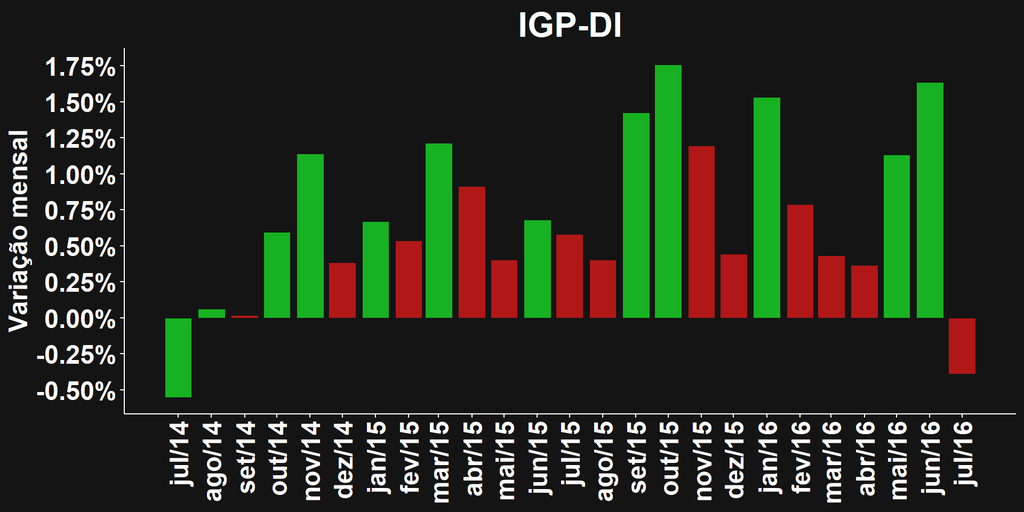

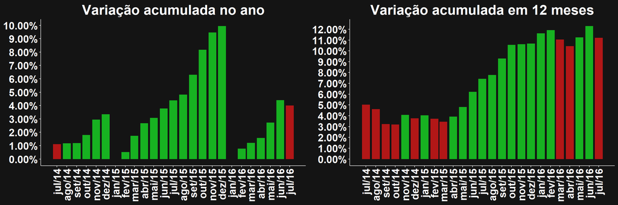

O Indíce de Preços de Atacado (IPA), integrante do IGP-DI com peso de 60%, apresentou variação de -0.81% em julho, valor inferior ao mesmo período do ano anterior quando apresentou uma taxa de 0.61%. Com esse resultado o indíce acumula no ano uma variação positiva de 0.06%, e em 12 meses uma variação positiva de 0.13%.

|  | 07/2015 | 06/2016 | 07/2016 |
| --- | --- | --- | --- |
| Variação mensal | 0.61% | 2.1% | -0.81% |
| Variação acumulada no ano | 0.04% | 0.07% | 0.06% |
| Variação acumulada em 12 meses | 0.07% | 0.15% | 0.13% |

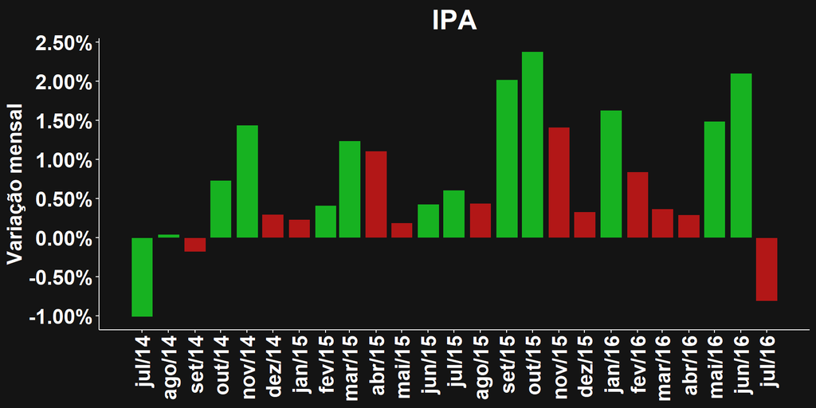

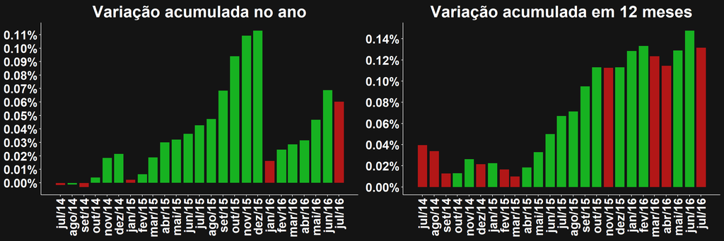

|  | 07/2015 | 06/2016 | 07/2016 |
| --- | --- | --- | --- |
| Variação mensal | 0.53% | 0.26% | 0.37% |
| Variação acumulada no ano | 5.16% | 2.67% | 3.05% |
| Variação acumulada em 12 meses | 9.61% | 8.54% | 8.37% |

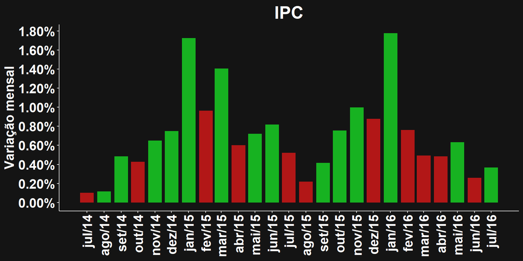

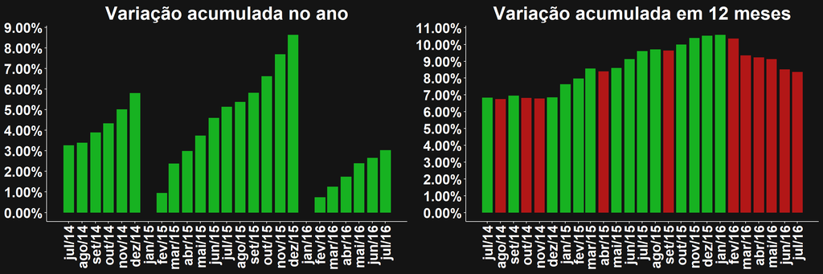

|  | 07/2015 | 06/2016 | 07/2016 |
| --- | --- | --- | --- |
| Variação mensal | 0.55% | 1.93% | 0.49% |
| Variação acumulada no ano | 4.81% | 3.78% | 4.29% |
| Variação acumulada em 12 meses | 6.76% | 6.46% | 6.4% |

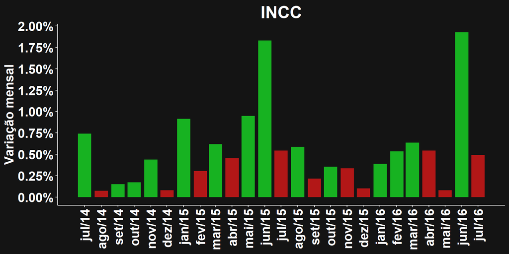

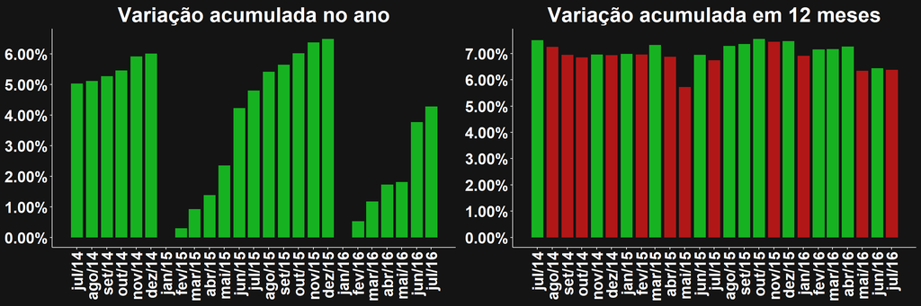

# Estatísticas

As estatísticas descritivas a seguir são feitas com base nos últimos 48 meses, e tem como objetivo possibilitar a avaliação do resultado observado em comparação aos períodos anteriores.

|  | Minimo | 1 Quartil | Mediana | Media | 3 Quartil | Maximo | Desvio Padrão |
| --- | --- | --- | --- | --- | --- | --- | --- |
| IPCA | 0.01% | 0.43% | 0.58% | 0.62% | 0.79% | 1.32% | 0.3% |
| INPC | -0.13% | 0.47% | 0.62% | 0.64% | 0.77% | 1.51% | 0.34% |
| IGP-M | -0.74% | 0.25% | 0.5% | 0.59% | 0.95% | 1.89% | 0.58% |
| IGP-DI | -0.63% | 0.3% | 0.5% | 0.58% | 0.89% | 1.76% | 0.57% |
| IPA | -1.21% | 0.12% | 0.42% | 0.56% | 1.11% | 2.38% | 0.85% |
| IPC | -0.17% | 0.41% | 0.55% | 0.62% | 0.76% | 1.78% | 0.37% |
| INCC | 0.08% | 0.26% | 0.45% | 0.58% | 0.65% | 2.25% | 0.51% |

Levando em consideração o desvio padrão de cada indíce, proporcionalmente os que mais se afastaram da média foram o IGP-DI, o IPA e o IGP-M.

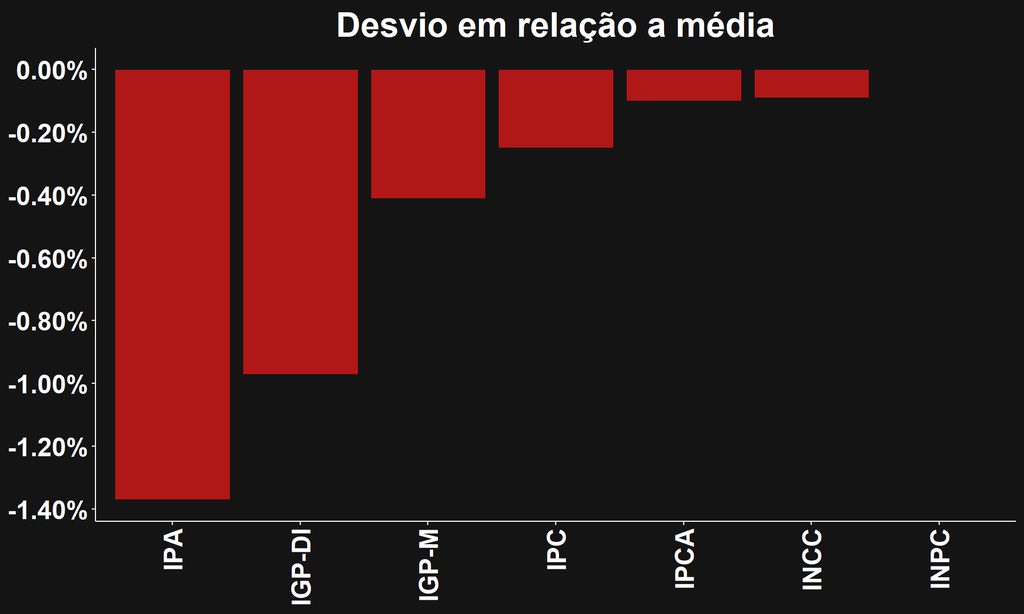

**João Victor Gomes**  
**jvg.santana@gmail.com**  
**[linkedin.com/in/jvictorgomes](https://www.linkedin.com/in/jvictorgomes/)**